# Data quality

[back to Home page |](https://github.com/huiwen-goy/C2-multidomain) [back to Analyses page |](https://huiwen-goy.github.io/C2-multidomain/C2-11Analyses.html) [Data quality |](https://huiwen-goy.github.io/C2-multidomain/C2-1Quality.html)

[Demographics |](https://huiwen-goy.github.io/C2-multidomain/C2-2Demographic.html) [Physical health |](https://huiwen-goy.github.io/C2-multidomain/C2-3Physical.html) [Hearing |](https://huiwen-goy.github.io/C2-multidomain/C2-4Hearing.html) [Cognition |](https://huiwen-goy.github.io/C2-multidomain/C2-5Cognition.html) [Mobility and balance |](https://huiwen-goy.github.io/C2-multidomain/C2-6Mobility.html) [Quality of life |](https://huiwen-goy.github.io/C2-multidomain/C2-7QoL.html) [Mental health |](https://huiwen-goy.github.io/C2-multidomain/C2-8Mental.html) [Social |](https://huiwen-goy.github.io/C2-multidomain/C2-9Social.html) [Views |](https://huiwen-goy.github.io/C2-multidomain/C2-10Views.html)

# Overview of responses

The Qualtrics survey was emailed to 1968 participants, based on a list of Stigma participants who consented to participate in further research and provided emails. 527 participants (26.8%) consented to participate in this survey. For the remainder, 212 emails failed; 3 emails were considered duplicates and skipped by Qualtrics; 2 opted out via Qualtrics; 26 responded to the invitation but declined to participate; and there was no response from the rest, except for a few who emailed the study coordinator directly to decline.

# Missingness

There are 214 items in the survey that are not conditional (appearing if the participant responded “yes” to a previous question). The table below shows the percentages of responses that are missing for non-conditional, i.e., no response at all, not even clicking on a true “N/A” option, which does appear on some scales such as the 15i-SSQ.

**Dropdown: Missing responses per item**

|  | % Missing |
| --- | --- |
| Demo_1_gender | 0.4 |
| Demo_2_year | 0.8 |
| Demo_3_employ | 0.4 |
| Demo_4_volunteer | 0.4 |
| Demo_5_first_visit | 0.4 |
| Demo_6_marital | 0.4 |
| Phys_1_rate | 2.1 |
| Phys_2_comorb_1 | 0.6 |
| Phys_2_comorb_2 | 0.9 |
| Phys_2_comorb_3 | 1.3 |
| Phys_2_comorb_4 | 1.1 |
| Phys_2_comorb_5 | 1.3 |
| Phys_2_comorb_6 | 1.3 |
| Phys_2_comorb_7 | 1.3 |
| Phys_2_comorb_8 | 1.5 |
| Phys_2_comorb_9 | 1.5 |
| Phys_2_comorb_10 | 1.3 |
| Phys_2_comorb_11 | 1.3 |
| Phys_2_comorb_12 | 1.3 |
| Phys_2_comorb_13 | 1.3 |
| Phys_2_comorb_14 | 1.3 |
| Phys_2_comorb_15 | 1.3 |
| Phys_2_comorb_16 | 1.5 |
| Phys_2_comorb_17 | 1.3 |
| Phys_2_comorb_18 | 1.3 |
| Phys_2_comorb_19 | 1.1 |
| Phys_2_comorb_20 | 1.3 |
| Phys_2_comorb_21 | 1.3 |
| Phys_2_comorb_22 | 1.3 |
| Phys_2_comorb_23 | 1.5 |

[output cut: 184 more lines]

# Time to completion

back to top

A few participants likely left the questionnaire open on their browser, so Qualtrics recorded extremely long durations. But 80% of participants spent less than an hour on the survey.

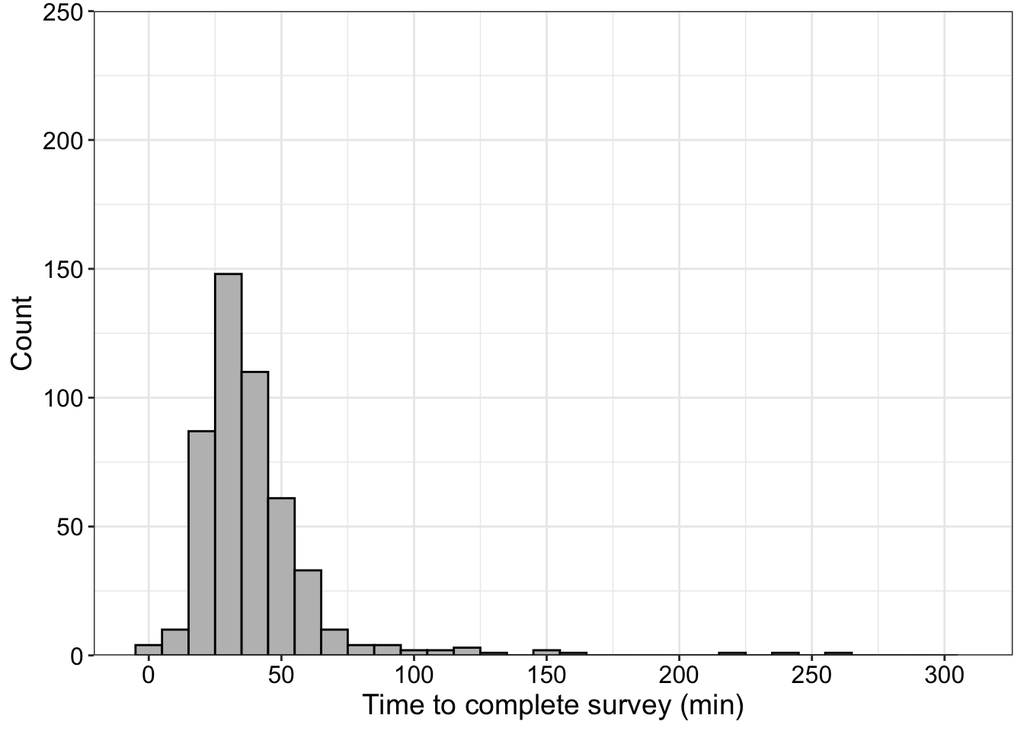

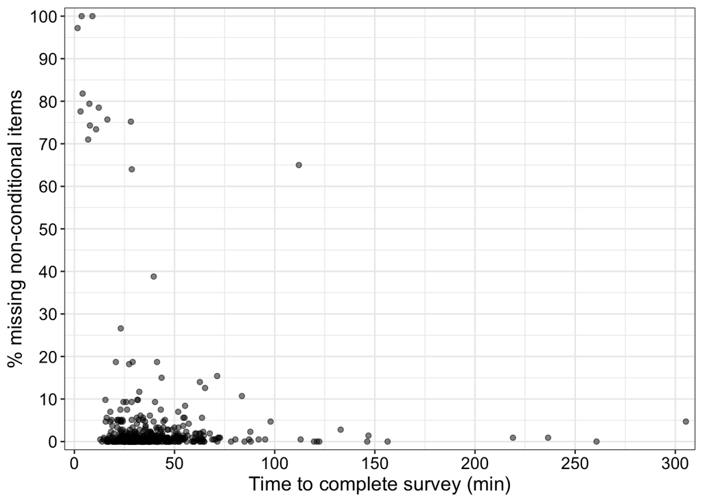

# Other variables available

back to top

- Reason for first visit to CH